# Reproducable Research Assignment (Week 2)

This is a project on a dataset of `moement sensors in wearable devices’. The dataset loaded contained the number of steps in 5-min intervals for a couple of days. The variablesa re the number of steps, date, and intervals.

In this project we compare the mean of the number of steps throughout a typical day. Also we try to impute data by replacing *NA* values with some reasonable values. We compare results for different days of weeks.

## Read files

In this part, we read the source file from web. Next we unzip the zip file, and read the csv file into *df* var.

```r
link1 <- "https://d396qusza40orc.cloudfront.net/repdata%2Fdata%2Factivity.zip"
download.file( url = link1,destfile = "activity.zip")
df_original <- read.csv(unzip("activity.zip"))
```

## What is mean total number of steps taken per day?

In this part, we remove **NA** values here. Then we obtain the total number of steps for each day. The mean and median number of steps are also computed.

```r
df <- df_original[!is.na(df_original[,1]),]
StepDaily <-  tapply(df$steps,df$date,sum)
print("Number of steps per day:")
```

```
## [1] "Number of steps per day:"
```

```r
StepDaily
```

```
## 2012-10-01 2012-10-02 2012-10-03 2012-10-04 2012-10-05 2012-10-06
##         NA        126      11352      12116      13294      15420
## 2012-10-07 2012-10-08 2012-10-09 2012-10-10 2012-10-11 2012-10-12
##      11015         NA      12811       9900      10304      17382
## 2012-10-13 2012-10-14 2012-10-15 2012-10-16 2012-10-17 2012-10-18
##      12426      15098      10139      15084      13452      10056
## 2012-10-19 2012-10-20 2012-10-21 2012-10-22 2012-10-23 2012-10-24
##      11829      10395       8821      13460       8918       8355
## 2012-10-25 2012-10-26 2012-10-27 2012-10-28 2012-10-29 2012-10-30
##       2492       6778      10119      11458       5018       9819
## 2012-10-31 2012-11-01 2012-11-02 2012-11-03 2012-11-04 2012-11-05
##      15414         NA      10600      10571         NA      10439
## 2012-11-06 2012-11-07 2012-11-08 2012-11-09 2012-11-10 2012-11-11
##       8334      12883       3219         NA         NA      12608
## 2012-11-12 2012-11-13 2012-11-14 2012-11-15 2012-11-16 2012-11-17
##      10765       7336         NA         41       5441      14339
## 2012-11-18 2012-11-19 2012-11-20 2012-11-21 2012-11-22 2012-11-23
##      15110       8841       4472      12787      20427      21194
## 2012-11-24 2012-11-25 2012-11-26 2012-11-27 2012-11-28 2012-11-29
##      14478      11834      11162      13646      10183       7047
## 2012-11-30
##         NA
```

### mean of steps:

```r
mean(StepDaily,na.rm = T)
```

```
## [1] 10766.19
```

median of steps:

```r
median(StepDaily,na.rm = T)
```

```
## [1] 10765
```

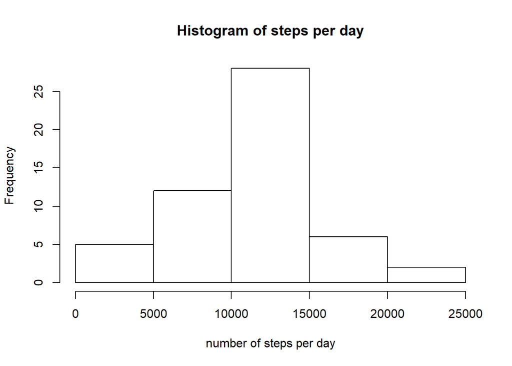

```r
hist(StepDaily, xlab = "number of steps per day", main = "Histogram of steps per day")
```

## What is the average daily activity pattern?

In this part, we compare the activity pattern thourghout a typical day by average of the number of steps durign 5-min intervals.

```r
library(dplyr)
```

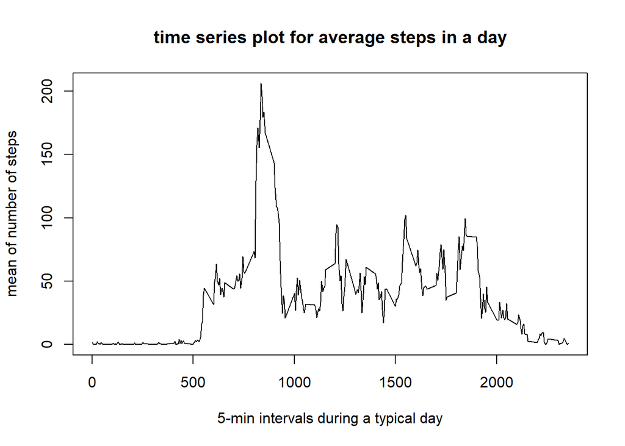

```r
TS <- df %>% group_by(interval) %>% summarise(meanSteps = mean(steps))
plot(TS$interval,TS$meanSteps,type="l",xlab = "5-min intervals during a typical day", ylab = "mean of number of steps", main = "time series plot for average steps in a day")
```

The 5-min Interval with maximum Mean Steps (mean over all days) is

```r
as.numeric(TS[ TS$meanSteps == max(TS$meanSteps), 1])
```

```
## [1] 835
```

## Imputing missing values

In this part, we impute data to replace *NA* values with a reasonable. We replace missing values with the average of steps for similar interval over all days.

The total number of rows with *NA* steps is

```r
sum(is.na(df_original$steps))
```

```
## [1] 2304
```

Here we create a new dataset from the original dataset by replacing *NA* values of **Steps** with the average steps for the same interval over all days

```r
imputDF <- left_join(df_original,TS, by = "interval")
imputDF[is.na(imputDF[,1]),1] <- imputDF[is.na(imputDF[,1]),4]
imputDF <- imputDF[,-4]
```

### A histogram of *Steps*, the mean and median of steps

mean of steps:

```r
impSumm <- imputDF %>% group_by(date) %>% summarise(SumStp = sum(steps))
mean(impSumm$SumStp)
```

```
## [1] 10766.19
```

median of steps:

```r
median(impSumm$SumStp )
```

```
## [1] 10766.19
```

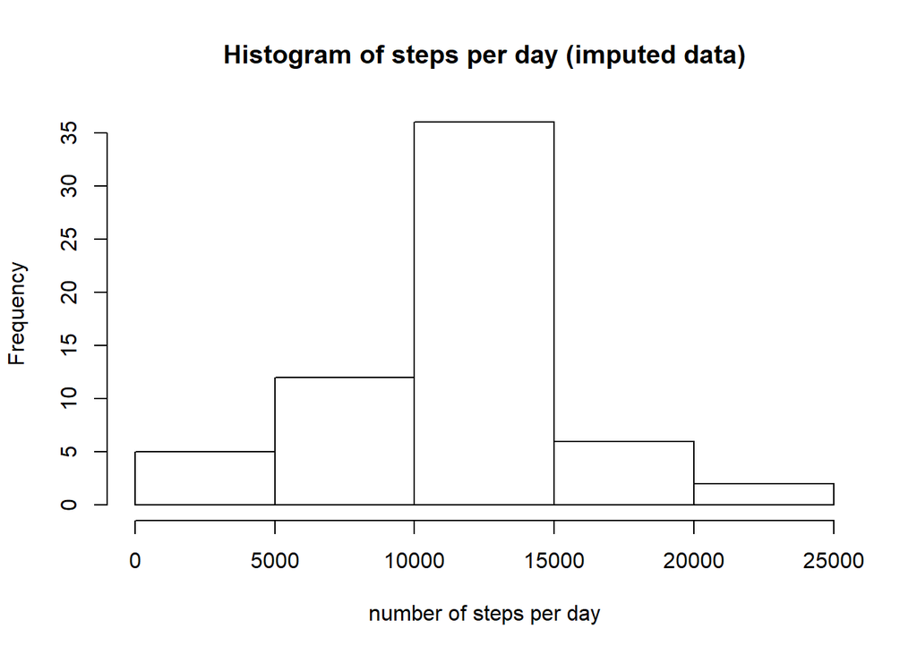

```r
hist(impSumm$SumStp, xlab = "number of steps per day", main = "Histogram of steps per day (imputed data)")
```

## Activity patterns between weekdays and weekends

An interesting question is how the activity pattern changes according to weekend or weekday. Here are answers:

```r
imputDF$weekNm <- weekdays(as.Date(imputDF$date))
weekD <- c("Tuesday","Monday","Friday","Wednesday","Thursday")
weekend <- c("Saturday","Sunday")
imputDF[imputDF$weekNm %in% weekD,5] <- "weekday"
imputDF[imputDF$weekNm %in% weekend,5] <- "weekend"
imputDF <- imputDF[,-4]
names(imputDF) <- c("steps","date","interval","day_week")
```

## Time series plot of the average number of steps across all weekdays or weekends

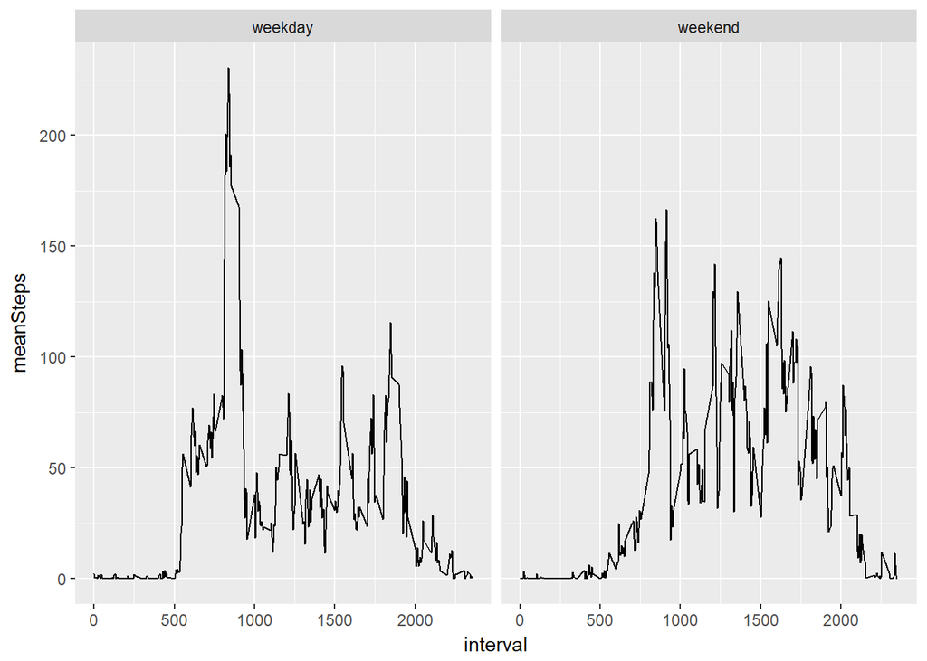

```r
dfAve <- imputDF %>% group_by(interval,day_week) %>% summarise(meanSteps = mean(steps))
par(mfrow = c(1, 2))
library(ggplot2)
qplot( interval, meanSteps, facets = .~day_week,data=dfAve,geom = "line"  )
```